# KRG_mirdeep_filtering_and_smallRNA_abundance

KRG

11/30/2019

## Prepare files for miRDeep2, which takes uncollapsed short fastqs

Additionally, see CLIPflexR documentation for:  
[CTK’s stripBarcode.pl](https://kathrynrozengagnon.github.io/CLIPflexR/reference/ctk_stripBarcode.html)  
[FASTX’s fastx_barcode_splitter.pl](https://kathrynrozengagnon.github.io/CLIPflexR/reference/fastx_barcode_splitter.html)  
[FASTX’s fastx_clipper](https://kathrynrozengagnon.github.io/CLIPflexR/reference/fastx_clipper.html) [FASTX’s fastx_trimmer](https://kathrynrozengagnon.github.io/CLIPflexR/reference/fastx_trimmer.html) [Revmap_process](https://kathrynrozengagnon.github.io/CLIPflexR/reference/revmap_process.html)

```r
# #took uncollapsed, QF fastq, converted to fasta in command line:
# #for i in QF*
# #do
# #fastq_to_fasta -Q33 -n -v -i "$i" -o "$i"".fa"
# #done
#
# #for i in QF*.fa
# #do
# #fastx_renamer -n COUNT -i "$i" -o "rn_""$i"
# #done
#
# #sbatch /rugpfs/fs0/home/krozen/fasta_rename.sh
#
# #for BrdU libraries, stripBarcode now
#
# stripBarcode <- function(filesToRun,
#                                sb="stripBarcode.pl",
#                                PATHTOPERLLIB=NULL,
#                                stderr=file.path(getwd(),"stripBarcode_stderr"),
#                                stdout=file.path(getwd(),"stripBarcode_stdout"),
#                                linkerlength=7){
#   fileToRun <- filesToRun[1]
#   cmd <- sb
#
#   if(!file.exists(fileToRun)) stop("File does not exist")
#
#   exportPATH <- ifelse(!is.null(PATHTOPERLLIB),paste0("export PERL5LIB=",PATHTOPERLLIB,";"),"")
#
#   cmd2 <- paste0(exportPATH," ",
#                  cmd," ",
#                  " -len ",linkerlength," -v ",
#                  " ",fileToRun," ",
#                  paste(fileToRun,"_rm5",sep=""))
#   #"temp.rm")
#   temp <- system(cmd2,wait = TRUE,intern = TRUE)
#
#   return(temp)
# }
#
#
# Dir <- "/rugpfs/fs0/rice_lab/scratch/krozen/mirdeep_files"
# strip <- dir(Dir, pattern= "rn_QF_BrdU*", full.names = TRUE)
# bplapply(strip, stripBarcode, sb="/rugpfs/fs0/home/krozen/ctk-master/stripBarcode.pl",  PATHTOPERLLIB = "/rugpfs/fs0/home/krozen/czplib-master")
#
# #split uncollapsed by sample index for standard/BrdU CLIP
#
# fastx_barcode_splitter <- function(fileTofxc,bcFile,mismatches=0,
#                                    fxc="fastx_barcode_splitter.pl",
#                                    stderr=file.path(getwd(),"fastx_barcode_splitter_stderr"),
#                                    stdout=file.path(getwd(),"fastx_barcode_splitter_stdout")){
#
#   cmd <- fxc
#
#   if(!file.exists(fileTofxc))stop("File does not exist")
#
#   prefix <- gsub("QF_|\\.fasta|\\.fastq","",basename(fileTofxc))
#
#
#   cmd2 <- paste0("cat ",
#                  fileTofxc," ",
#                  "| ",
#                  cmd," ",
#                  " --bcfile ",bcFile," ",
#                  "--bol --mismatches ",mismatches," ",
#                  "--prefix '",prefix,"_' ")
#   temp <- system(cmd2,wait = TRUE,intern = TRUE)
#
#   return(temp)
# }
#
# #For each multiplexed fasta, ran this code with appropriate BC fie
# pathtoBC <- "/rugpfs/fs0/rice_lab/scratch/krozen/fastq_gz/QF_KRG-102219_S1_L001_R1_001.fasta"
# bcFile <- "/rugpfs/fs0/rice_lab/scratch/krozen/BC_files/KRG102219_BC.txt"
# fastx_barcode_splitter(pathtoBC, bcFile, fxc = "/ru-auth/local/home/krozen/bin/fastx_barcode_splitter.pl" )
#
# #then, stripbarcode for standard libraries
# stripBarcode <- function(filesToRun,
#                                sb="stripBarcode.pl",
#                                PATHTOPERLLIB=NULL,
#                                stderr=file.path(getwd(),"stripBarcode_stderr"),
#                                stdout=file.path(getwd(),"stripBarcode_stdout"),
#                                linkerlength=27){
#   fileToRun <- filesToRun[1]
#   cmd <- sb
#
#   if(!file.exists(fileToRun)) stop("File does not exist")
#
#   exportPATH <- ifelse(!is.null(PATHTOPERLLIB),paste0("export PERL5LIB=",PATHTOPERLLIB,";"),"")
#
#   cmd2 <- paste0(exportPATH," ",
#                  cmd," ",
#                  " -len ",linkerlength," -v ",
#                  " ",fileToRun," ",
#                  paste(fileToRun,"_rm5",sep=""))
#   #"temp.rm")
#   temp <- system(cmd2,wait = TRUE,intern = TRUE)
#
#   return(temp)
# }
#
# Dir <- "/rugpfs/fs0/rice_lab/scratch/krozen/mirdeep_files"
# strip <- dir(Dir, pattern= "^KRG", full.names = TRUE)
# strip <- grep("unmatched", strip, value = TRUE, invert = TRUE)
# strip <- grep("Exp6", strip, value = TRUE, invert = TRUE)
# strip <- grep("Exp5", strip, value = TRUE, invert = TRUE)
#
# template <- "/rugpfs/fs0/home/krozen/simple_kate.tmpl"
# param <- BatchtoolsParam(workers=10000, cluster="slurm",template=template)
# register(param)
#
# bplapply(strip, stripBarcode, sb="/rugpfs/fs0/home/krozen/ctk-master/stripBarcode.pl",  PATHTOPERLLIB = "/rugpfs/fs0/home/krozen/czplib-master")
#
#
# #now clip 3' linker from standard files
#
# fastx_clipper <- function(fileTofqs,fqc="fastx_clipper",length=18,
#                           adaptor="GTGTCAGTCACTTCCAGCGG",
#                           stderr=file.path(getwd(),"clipper_stats_stderr"),
#                           stdout=file.path(getwd(),"clipper_stats_stdout")){
#   cmd <- fqc
#
#   if(!file.exists(fileTofqs))stop("File does not exist")
#
#   file_fqs <- file.path(dirname(fileTofqs),gsub("rm5","rm5_rm3.fa",basename(fileTofqs)))
#   if(file.exists(fileTofqs) & !file.exists(file_fqs)){
#
#     args <- c(
#       paste0("-l ",length),
#       paste0("-a  ",adaptor),
#       paste0("-o ",file_fqs),
#       paste0("-i ",fileTofqs)
#     )
#     print(cmd)
#     print(args)
#
#     system2(cmd,
#             args,
#             stdout=stdout,
#             stderr=stderr
#     )
#   }
#   return(file_fqs)
# }
#
# #R command to clip linker:
# Dir <- "/rugpfs/fs0/rice_lab/scratch/krozen/mirdeep_files"
# clip <- dir(Dir, pattern= "*rm5", full.names = TRUE)
# clip <- grep("BrdU_", clip, value = TRUE, invert = TRUE)
#
# bplapply(clip, fastx_clipper, fqc = "/rugpfs/fs0/home/krozen/bin/fastx_clipper")
#
# #then trim and clip BrdU libraries
# fastx_trimmer <- function(fileTofqt,fqt="fastx_trimmer",length=10,
#                           stderr=file.path(getwd(),"trimmer_stats_stderr"),
#                           stdout=file.path(getwd(),"trimmer_stats_stdout")){
#   cmd <- fqt
#
#   if(!file.exists(fileTofqt))stop("File does not exist")
#
#   file_fqt <- file.path(dirname(fileTofqt),paste0(basename(fileTofqt), "_rm5.fa"))
#   if(file.exists(fileTofqt) & !file.exists(file_fqt)){
#
#     args <- c(
#       paste0("-f ",length),
#       paste0("-o ",file_fqt),
#       paste0("-i ",fileTofqt)
#     )
#     print(cmd)
#     print(args)
#
#     system2(cmd,
#             args,
#             stdout=stdout,
#             stderr=stderr
#     )
#   }
#   return(file_fqt)
# }
#
# Dir <- "/rugpfs/fs0/rice_lab/scratch/krozen/mirdeep_files"
# trim <- dir(Dir, pattern= "*rm5", full.names = TRUE)
# trim <- grep("BrdU_", trim, value = TRUE)
#
# bplapply(trim, fastx_trimmer, fqc = "/rugpfs/fs0/home/krozen/bin/fastx_trimmer")
#
# #Now clip BrdU
# Dir <- "/rugpfs/fs0/rice_lab/scratch/krozen/mirdeep_files"
# clip <- dir(Dir, pattern= "*rm5", full.names = TRUE)
# clip <- grep("BrdU_", clip, value = TRUE)
#
# bplapply(clip, fastx_clipper, fqc = "/rugpfs/fs0/home/krozen/bin/fastx_clipper")
#
# # get short sequences and remove linker concatemers (if any)
#
# fastaProcess <- function(input) {
#   require(Biostrings)
#   seq <-  "GGACGATGC" #this was a linker sequence that formed concatemers, especially in IgG samples; remove
#   fa <- readDNAStringSet(input, format = "fasta", nrec = -1L)
#   fa <- fa[width(fa) <= 30]
#   fa <- as.character(fa)
#   fa <- grep(seq, fa, value = TRUE, invert = TRUE)
#  fa <- DNAStringSet(fa)
#   outname = paste(input, sep = "")
#   outname = gsub("rm5_rm3.fa", "short_rmlinker.fa", outname)
#   writeXStringSet(fa, outname)
# }

#Dir <- "/rugpfs/fs0/rice_lab/scratch/krozen/mirdeep_files""
#fapro <- dir(Dir, pattern= "*rm5_rm3.fa, full.names = TRUE)
#for (i in 1:length(fapro)) {
#   fastaProcess(fapro[i])
# }
```

## Align uncollapsed files split by sample to genome using Rbowtie2

“Aedes-aegypti-LVP_AGWG_CHROMOSOMES_AaegL5.fa” was used to make index and is available for download at [Vectorbase](https://vectorbase.org/vectorbase/app/downloads/)

Input miRDeep fastas “aae_miRNAs_mature_fixed.fa”, “dme_miRNAs_mature_fixed.fa”, and “aae_hairpin_fixed.fa” were downloaded from [miRBase](http://www.mirbase.org/ftp.shtml) and are available in my [Github](https://github.com/kathrynrozengagnon/AGOCLIP_2020/tree/master/renamed_smallRNA_fastas)

Additionally, see CLIPflexR documentation for:  
[bowtie2_index](https://kathrynrozengagnon.github.io/CLIPflexR/reference/bowtie2_index.html)  
[bowtie_align](https://kathrynrozengagnon.github.io/CLIPflexR/reference/bowtie_align.html)

```r
# bowtie_align <- function(fq,index,sam=gsub("\\.fq|\\.fastq|\\.rm|\\.fa",".sam",fq)
# ) {
#   require(Rbowtie2)
#   if(!dir.exists(sam)){
#     bowtie2(bt2Index = index,
#             samOutput = sam,
#             seq1 = fq,"--threads 4 -f -L 18")
#     Rsamtools::asBam(sam,gsub("\\.sam","",sam))
#   }
#
# }
#
# Dir <- "/rugpfs/fs0/rice_lab/scratch/krozen/mirdeep_files"
# fqfiles <- dir(Dir, pattern= "*short_rmlinker.fa", full.names = TRUE)
# bplapply(fqfiles, bowtie_align, index = "/rugpfs/fs0/rice_lab/scratch/krozen/AaegL5_ref/Aedes-aegypti-LVP_AGWG_CHROMOSOMES_AaegL5")

#need to convert mapped reads (sams) to miRDeep2 collapsed format to get collapsed fasta and collapsed mapped read formtat (arf) using their bwa_sam_converter.pl script

# sams <- dir("/rugpfs/fs0/rice_lab/scratch/krozen/mirdeep_files", pattern="*.sam$", full.names = FALSE)
#
# bwa_sam_converter <- function(sam){
#   cmd <- paste0("perl /rugpfs/fs0/home/krozen/mirdeep2/bin/bwa_sam_converter.pl ",
#                 "-i ", sam,
#                " -c -o ",
#                gsub(".sam","reads_collapsed.fa",sam)," -a ",
#                gsub(".sam","sam_vs_genome.arf",sam))
#   system(cmd,intern = TRUE)
# }
#
# Dir <- "/rugpfs/fs0/rice_lab/scratch/krozen/mirdeep_files"
# setwd(Dir)
#
# for (i in 1:length(sams)) {
#   bwa_sam_converter(sams[i])
# }

# #run miRDeep2.pl
#
# Dir <- "/rugpfs/fs0/rice_lab/scratch/krozen/mirdeep_files"
#
# FA <- dir(Dir, pattern="sam_collapsed.fa", full.names = TRUE)
#
# mirdeep <- function(mFA){
#   genome <- "Aedes-aegypti-LVP_AGWG_CHROMOSOMES_AaegL5_fixed.fa"
#   files <- "/rugpfs/fs0/rice_lab/scratch/krozen/mirdeep_files/aae_miRNAs_mature_fixed.fa /rugpfs/fs0/rice_lab/scratch/krozen/mirdeep_files/dme_miRNAs_mature_fixed.fa /rugpfs/fs0/rice_lab/scratch/krozen/mirdeep_files/aae_hairpin_fixed.fa"
#   cv <- gsub("sam_collapsed.fa","sam_vs_genome.arf",mFA)
#   log <- gsub("sam_collapsed.fa","_report.log",mFA)
#   cmd <- paste0("/rugpfs/fs0/home/krozen/mirdeep2/bin/miRDeep2.pl ",
#                 mFA," ",
#                 genome," ",
#                 cv," ",
#                 files," -v ",
#                 "2>",log
#   )
#   system(cmd,wait = T)
# }
#
# for (i in 1:length(FA)) {
#   mirdeep(FA[i])
# }
```

output miRDeep2 csv files “ind_bowtie2_csv.zip” are provided in my [Github](https://github.com/kathrynrozengagnon/AGOCLIP_2020)

## Concatenate uncollapsed, processed reads by sample type (Ab/lysate) and map to genome using Rbowtie2

```r
#define file groups
# FA <- dir(Dir,pattern="_short_rmlinker.fa",full.names = TRUE)
#
# Ago1 <- grep("Ago1", FA, value=TRUE) #32
# Ago1_aegypti <- grep("aegypti", Ago1, value=TRUE) #15
# Ago1_Aag2 <- grep("Aag2", Ago1, value=TRUE) #17
#
# Ago2 <- grep("Ago2", FA, value=TRUE) #20
# Ago2_aegypti <- grep("aegypti", Ago2, value=TRUE)#8
# Ago2_Aag2 <- grep("Aag2", Ago2, value=TRUE) #12
#
# rIgG <- grep("rIgG", FA, value=TRUE)  #23
# rIgG_aegypti <- grep("aegypti", rIgG, value=TRUE)  #8
# rIgG_Aag2 <- grep("Aag2", rIgG , value=TRUE) #15
#
# mIgG <- grep("mIgG",FA, value=TRUE) #22
# mIgG_aegypti <- grep("aegypti", mIgG, value=TRUE) #10
# mIgG_Aag2 <- grep("Aag2", mIgG, value=TRUE) #12
#
# #read in as a group
# Ago1_aegypti <- lapply(Ago1_aegypti, readDNAStringSet, format = "fasta", nrec = -1L)
# Ago1_Aag2 <- lapply(Ago1_Aag2, readDNAStringSet, format = "fasta", nrec = -1L)
# Ago2_Aag2 <- lapply(Ago2_Aag2, readDNAStringSet, format = "fasta", nrec = -1L)
# Ago2_aegypti <- lapply(Ago2_aegypti, readDNAStringSet, format = "fasta", nrec = -1L)
# rIgG_aegypti <- lapply(rIgG_aegypti, readDNAStringSet, format = "fasta", nrec = -1L)
# mIgG_aegypti <- lapply(mIgG_aegypti, readDNAStringSet, format = "fasta", nrec = -1L)
# rIgG_Aag2 <- lapply(rIgG_Aag2, readDNAStringSet, format = "fasta", nrec = -1L)
# mIgG_Aag2 <- lapply(mIgG_Aag2, readDNAStringSet, format = "fasta", nrec = -1L)
#
# Ago1_aegypti <- do.call(c, Ago1_aegypti)
# Ago1_Aag2 <- do.call(c, Ago1_Aag2)
# Ago2_aegypti <- do.call(c, Ago2_aegypti)
# Ago2_Aag2 <- do.call(c, Ago2_Aag2)
# rIgG_aegypti <- do.call(c, rIgG_aegypti)
# mIgG_aegypti <- do.call(c, mIgG_aegypti)
# rIgG_Aag2  <- do.call(c, rIgG_Aag2)
# mIgG_Aag2   <- do.call(c, mIgG_Aag2)
#
# test <- Filter(function(x) is(x, "DNAStringSet"), mget(ls()))
#
# names(test) <- paste0(Dir, "/cat_short_rmlinker_", names(test))

# for (i in names(test)) {
#   writeXStringSet(test[[i]], filepath = paste0(Dir,"/cat_short_rmlinker_",i, ".fasta"), format = "fasta")
# }

#then, map as before:
#  bowtie_align <- function(fq,index,sam=gsub("\\.fq|\\.fastq|\\.rm|\\.fasta",".sam",fq)
# ) {
#   require(Rbowtie2)
#   if(!dir.exists(sam)){
#     bowtie2(bt2Index = index,
#             samOutput = sam,
#             seq1 = fq,"--threads 4 -f -L 18")
#     Rsamtools::asBam(sam,gsub("\\.sam","",sam))
#   }
#
# }
#
# Dir <- "/rugpfs/fs0/rice_lab/scratch/krozen/mirdeep_files/cat_bowtie2"
# fqfiles <- dir(Dir,
#            pattern="cat_short_rmlinker_*",
#            full.names = TRUE)
# bplapply(fqfiles, bowtie_align, index = "/rugpfs/fs0/rice_lab/scratch/krozen/AaegL5_ref/Aedes-aegypti-LVP_AGWG_CHROMOSOMES_AaegL5")

##then reformat to mirdeep format
# catsams <- dir("/rugpfs/fs0/rice_lab/scratch/krozen/mirdeep_files", pattern="*.sam$", full.names = FALSE)
# catsams <- grep("cat_short_rmlinker_*", catsams)
# for (i in 1:length(catsams)) {
#   bwa_sam_converter(catsams[i])
# }

# #run  miRDeep2.pl
#
# Dir <- "/rugpfs/fs0/rice_lab/scratch/krozen/mirdeep_files/cat_bowtie2"
#
# cat_FA <- dir(Dir, pattern="*.sam_collapsed.fa", full.names = TRUE)
#
# for (i in 1:length(FA)) {
#   mirdeep(FA[i])
# }
#
```

output miRDeep2 csv files “cat_bowtie2_csv.zip” are provided in my [Github](https://github.com/kathrynrozengagnon/AGOCLIP_2020)

## Also used standard miRDeep2 method where all files are put together to run miRDeep2.pl, and a config.txt file is provided to assign ids; mapping was done by miRDeep2 method (Bowtie v1.2.2)

```r
#for cat config method, need to write config.txt file where I have the full file path to all files, then a 3 letter id
# Dir <- "/rugpfs/fs0/rice_lab/scratch/krozen/mirdeep_files/mirdeep_mapped"
# paths <- dir(Dir,pattern="*_short_rmlinker.fa",full.names = TRUE)
# df <- as.data.frame(df)
# df$id <- NA
# df$paths <- as.character(df$paths)
# temp <- strsplit(df$paths, "/")
# mat  <- matrix(unlist(temp), ncol=9, byrow=TRUE)
# df <- cbind(df, mat)
# df <- df[,c(1:2, 11)]
# col.names <- colnames(df)
# col.names <- gsub("9", "sample", col.names)
# df <- setNames(df, col.names)
# df$sample <- as.character(df$sample)
# df$sample <- gsub("BrdU_", "", df$sample)
# temp <- strsplit(df$sample, "_")
# mat  <- matrix(unlist(temp), ncol=6, byrow=TRUE)
# mat <- mat[,1:4]
# df <- cbind(df, mat)
# col.names <- colnames(df)
# col.names <- col.names[1:3]
# col.names <- c(col.names, "ExpId", "Lysate", "Antibody", "ExpRep", "group")
# df$group <- paste0(df$Lysate, df$Antibody)
# df_group <- df %>% group_by(group)
# df_group <-  arrange(df_group, ExpRep, .by_group = TRUE)
#
# write.table(df_group, file = "/rugpfs/fs0/rice_lab/scratch/krozen/mirdeep_files/mirdeep_mapped/check_order.txt", quote = FALSE, sep = "\t", col.names = TRUE, row.names = TRUE)
# df_group <- df_group %>% group_by(group) %>% mutate(id = row_number())
# df_group$id <- sprintf("%02d" , df_group$id)
#
# df_group$group_id <- NA
#
# df_group$group_id[str_match(df_group$group, "Aag2Ago1")=="Aag2Ago1"] <- "A"
# df_group$group_id[str_match(df_group$group, "Aag2Ago2")=="Aag2Ago2"] <- "B"
# df_group$group_id[str_match(df_group$group, "Aag2mIgG")=="Aag2mIgG"] <- "C"
# df_group$group_id[str_match(df_group$group, "Aag2rIgG")=="Aag2rIgG"] <- "D"
# df_group$group_id[str_match(df_group$group, "aegyptiAgo1")=="aegyptiAgo1"] <- "E"
# df_group$group_id[str_match(df_group$group, "aegyptiAgo2")=="aegyptiAgo2"] <- "F"
# df_group$group_id[str_match(df_group$group, "aegyptimIgG")=="aegyptimIgG"] <- "G"
# df_group$group_id[str_match(df_group$group, "aegyptirIgG")=="aegyptirIgG"] <- "H"
#
# is.na(df_group$group_id) #all FALSE
#
# config <- df_group[,1:2]
#
# write.table(config, file = "/rugpfs/fs0/rice_lab/scratch/krozen/mirdeep_files/mirdeep_mapped/config.txt", quote = FALSE, sep = "\t", col.names = FALSE, row.names = FALSE)

#cat all files together and map using mirdeep mapper script

# mapper <- function(mFA){
#   genome <- "/rugpfs/fs0/rice_lab/scratch/krozen/mirdeep_files/AaegL5"
#   config <- "/rugpfs/fs0/rice_lab/scratch/krozen/mirdeep_files/mirdeep_mapped/config.txt"
#   arf <- "/rugpfs/fs0/rice_lab/scratch/krozen/mirdeep_files/mirdeep_mapped/cat.arf"
#   fa <- "/rugpfs/fs0/rice_lab/scratch/krozen/mirdeep_files/mirdeep_mapped/cat_collapsed.fa"
#   cmd <- paste0("/rugpfs/fs0/home/krozen/mirdeep2/bin/mapper.pl ",
#                 config," -c -d -j -m -l 18 -p ",
#                 genome," -s ", fa, " -t ",
#                 arf, " -v"
#   )
#   system(cmd,wait = T)

#run miRDeep2.pl on collapsed fa and arf that were generated
#
# input <- "/rugpfs/fs0/rice_lab/scratch/krozen/mirdeep_files/mirdeep_mapped/cat_collapsed.fa"
# genome <- "/rugpfs/fs0/rice_lab/scratch/krozen/mirdeep_files/Aedes-aegypti-LVP_AGWG_CHROMOSOMES_AaegL5_fixed.fa"
#   files <- "/rugpfs/fs0/rice_lab/scratch/krozen/mirdeep_files/aae_miRNAs_mature_fixed.fa /rugpfs/fs0/rice_lab/scratch/krozen/mirdeep_files/dme_miRNAs_mature_fixed.fa /rugpfs/fs0/rice_lab/scratch/krozen/mirdeep_files/aae_hairpin_fixed.fa"
#   arf <- gsub("_collapsed.fa",".arf",input)
#   log <- gsub("_collapsed.fa","_report.log",input)
#   cmd <- paste0("/rugpfs/fs0/home/krozen/mirdeep2/bin/miRDeep2.pl ",
#                 input," ",
#                 genome," ",
#                 arf," ",
#                 files," -v ",
#                 "2>",log)
#   system(cmd,wait = T)
```

output “config.txt” file is available in my [Github](https://github.com/kathrynrozengagnon/AGOCLIP_2020)  
output miRDeep2 csv file “result_cat_mirdeep.csv” is also provided in my [Github](https://github.com/kathrynrozengagnon/AGOCLIP_2020)

## Get miRDeep2 results from each method and filter novel small RNAs discovered

see chunks above for all miRDeep2 csv outputs, which are read in and filtered in the following chunks  
Additional fastas with miRNAs from related species “aga_miRNAs_mature.fa” (*Anopheles gambiae*) and “cqu_mature_fixed.fa” (*Culex quinquefasciatus*) were downloaded from [miRBase](http://www.mirbase.org/ftp.shtml) and are available in my [Github](https://github.com/kathrynrozengagnon/AGOCLIP_2020/tree/master/renamed_smallRNA_fastas)

```r
#individual samples, Rbowtie2
Dir <- "/Users/kathryn/Reprocess_all_paper_datasets/mirdeep_results/ind_bowtie2"
csv <- dir(Dir, pattern="*.csv",full.names = TRUE)
novel <- lapply(csv, fread, header=TRUE, sep="\t", skip = 26,strip.white = TRUE, data.table = FALSE)
col.names <- gsub("/Users/kathryn/Reprocess_all_paper_datasets/mirdeep_results/ind_bowtie2/result_", "", csv)
col.names<- gsub(".csv", "", col.names)
col.names<- gsub("BrdU_", "", col.names)
names(novel) <- col.names
#remove "empties" with no novel, if novel is discovered column will read "provisional id", otherwise will read "tag id" and have only known miRNAs
m <- lapply(novel, function(x) grep("provisional id", colnames(x), value=TRUE))
t <- unlist(m) #81
t <- names(t)
sub <-  names(novel) %in%  t
novel <- novel[sub]

novel <- rbindlist(novel, idcol=TRUE)

#format seeds in related species cols

aga <- readDNAStringSet("/Users/kathryn/mirdeep2_master/aga_miRNAs_mature.fa", format = "fasta", nrec = -1L)
aga_seeds <- subseq(aga, start=2, end=NA, width=6)
t <- novel$`consensus mature sequence`
t <- gsub("u", "t", t)
t <- toupper(t)
t <- DNAStringSet(t)
names(t) <- novel$`provisional id`
t_seeds <- subseq(t, start=2, end=NA, width=6)
novel$aga <- t_seeds %in% aga_seeds

cqu <- readDNAStringSet("/Users/kathryn/mirdeep2_master/cqu_mature_fixed.fa", format = "fasta", nrec = -1L)
cqu_seeds <- subseq(cqu, start=2, end=NA, width=6)
novel$cqu <- t_seeds %in% cqu_seeds

aae <- readDNAStringSet("/Users/kathryn/mirdeep2_master/aae_miRNAs_mature_fixed.fa", format = "fasta", nrec = -1L)
aae_seeds <- subseq(aae, start=2, end=NA, width=6)
novel$aae <- t_seeds %in% aae_seeds

## subset ones that are either score of above 0 and randfold sig, or with any matching seed in a related family

novel_filtered <- subset(novel, novel$`significant randfold p-value`=="yes" & novel$`miRDeep2 score` > 0 | novel$`example miRBase miRNA with the same seed`!="-" | novel$aga==TRUE | novel$aae ==TRUE | novel$cqu == TRUE)

#samples concatenated by Ab/lysate, Rbowtie2
Dir <- "/Users/kathryn/Reprocess_all_paper_datasets/mirdeep_results/cat_bowtie2_csv"
csv <- dir(Dir, pattern="*.csv",full.names = TRUE)
novel <- lapply(csv, fread, header=TRUE, sep="\t", skip = 26,strip.white = TRUE, data.table = FALSE)
```

```r
col.names <- gsub("/Users/kathryn/Reprocess_all_paper_datasets/mirdeep_results/cat_bowtie2_csv/result_", "", csv)
col.names<- gsub(".csv", "", col.names)
names(novel) <- col.names
m <- lapply(novel, function(x) grep("provisional id", colnames(x), value=TRUE))
t <- unlist(m)
t <- names(t)
sub <-  names(novel) %in%  t
novel <- novel[sub]

novel <- rbindlist(novel, idcol=TRUE)
t <- novel$`consensus mature sequence`
t <- gsub("u", "t", t)
t <- toupper(t)
t <- DNAStringSet(t)
names(t) <- novel$`provisional id`
t_seeds <- subseq(t, start=2, end=NA, width=6)

novel$aga <- t_seeds %in% aga_seeds
novel$cqu <- t_seeds %in% cqu_seeds
novel$aae <- t_seeds %in% aae_seeds

novel_filtered_cat <- subset(novel, novel$`significant randfold p-value`=="yes" & novel$`miRDeep2 score` > 0 | novel$`example miRBase miRNA with the same seed`!="-" | novel$aga==TRUE | novel$aae ==TRUE | novel$cqu == TRUE)

#now all samples concatenated, run with miRDeep2 mapper.pl and config.txt file
novel <- fread("/Users/kathryn/Reprocess_all_paper_datasets/mirdeep_results/mirdeep_mapped_cat_config/result_cat_mirdeep.csv", header=TRUE, sep="\t", skip = 26,strip.white = TRUE, data.table = FALSE)
t <- novel$`consensus mature sequence`
t <- gsub("u", "t", t)
t <- toupper(t)
t <- DNAStringSet(t)
names(t) <- novel$`provisional id`
t_seeds <- subseq(t, start=2, end=NA, width=6)
novel$aga <- t_seeds %in% aga_seeds
novel$cqu <- t_seeds %in% cqu_seeds
novel$aae <- t_seeds %in% aae_seeds

novel_filtered_mir <- subset(novel, novel$`significant randfold p-value`=="yes" & novel$`miRDeep2 score` > 0 | novel$`example miRBase miRNA with the same seed`!="-" | novel$aga==TRUE | novel$aae ==TRUE | novel$cqu == TRUE)

novel_filtered_mir$.id <- paste0("cat_mirdeep")
novel_filtered_mir <- novel_filtered_mir[,c(21, 1:20)]

all_novel <- rbind(novel_filtered, novel_filtered_cat, novel_filtered_mir)

#take unique novel and write to DNA stringset; add name of seq/sample coll where applicable
summary <- all_novel %>% group_by(`consensus mature sequence`) %>% summarise_each(funs(paste(., collapse = "; ")))
summary$DNA_seq <-  gsub("u", "t", summary$`consensus mature sequence`)
summary$DNA_seq <-  toupper(summary$DNA_seq)
summary$type1 <- NA
summary$type2 <- NA
summary$type1[str_match(summary$.id, "Ago1")=="Ago1"] <- "Ago1"
summary$type2[str_match(summary$.id, "Ago2")=="Ago2"] <- "Ago2"
summary$discovery_type <- paste0(summary$type1, ":", summary$type2)

summary$type1[str_match(summary$.id, "cat")=="cat"] <- "cat;TBD"
summary$type1[str_match(summary$discovery_type, "Ago1:NA")=="Ago1:NA"] <- "Ago1"
summary$type1[str_match(summary$discovery_type, "NA:Ago2")=="NA:Ago2"] <- "Ago2"
summary$type1[str_match(summary$discovery_type, "Ago1:Ago2")=="Ago1:Ago2"] <- "both"

#remove IgG only discoveries
toremove <- subset(summary$DNA_seq, is.na(summary$type1))
summary <- subset(summary, !is.na(summary$type1))

#write.table(summary, file = "/Users/kathryn/Reprocess_all_paper_datasets/mirdeep_results/novel_mirdeep_filtered.txt", quote = FALSE, sep = "\t", col.names = TRUE, row.names = TRUE)

towrite <- summary$`consensus mature sequence`
towrite <- gsub("u", "t", towrite)
towrite <- toupper(towrite)
towrite <- DNAStringSet(towrite, use.names = TRUE)
names(towrite) <- towrite
df <- as.data.frame(towrite)
all_seqs <- c(aae, towrite)

#writeXStringSet(all_seqs, "/Users/kathryn/Reprocess_all_paper_datasets/mirdeep_results/all_putative_known.fa", format="fasta")
```

output “all_putative_known.fa” is available in my [Github](https://github.com/kathrynrozengagnon/AGOCLIP_2020/tree/master/renamed_smallRNA_fastas) output file “novel_mirdeep_filtered.txt” is available in my [Github](https://github.com/kathrynrozengagnon/AGOCLIP_2020)

## Make table for seeds of all putative novel small RNAs and known miRNAs

see chunk above for “all_putative_known.fa” input file

```r
#make table of all seeds/target types for known and novel, unfiltered
all_sRNA <- readDNAStringSet("/Users/kathryn/Reprocess_all_paper_datasets/mirdeep_results/all_putative_known.fa", format = "fasta", nrec = -1L)
sRNA_FLRC <- reverseComplement(all_sRNA)
sRNA_FLRC_df <- as.data.frame(sRNA_FLRC)
sRNA_FLRC_df <- setNames(sRNA_FLRC_df, "FL_target")

all_seeds <- subseq(all_sRNA, start=2, end=NA, width=6)
all_seeds_df <- as.data.frame(all_seeds)
all_seeds_df <- setNames(all_seeds_df, "six_mer")

all_seeds_RC <- reverseComplement(all_seeds)
all_seeds_RC <- as.data.frame(all_seeds_RC)
all_seeds_RC <- setNames(all_seeds_RC, "six_mer_target")

all_seeds_df$seven_A1 <- paste0("T", all_seeds_df$six_mer)
all_seeds_7A1 <- DNAStringSet(all_seeds_df$seven_A1)
names(all_seeds_7A1) <- row.names(all_seeds_df)
all_seeds_7A1 <- reverseComplement(all_seeds_7A1)
all_seeds_7A1 <- as.data.frame(all_seeds_7A1)
all_seeds_7A1 <- setNames(all_seeds_7A1, "seven_A1_target")

all_seeds_7M8 <- subseq(all_sRNA, start=2, end=NA, width=7)
all_seeds_7M8_df <- as.data.frame(all_seeds_7M8)
all_seeds_7M8_df <- setNames(all_seeds_7M8_df, "seven_M8")

all_seeds_7M8_RC <- reverseComplement(all_seeds_7M8)
all_seeds_7M8_RC <- as.data.frame(all_seeds_7M8_RC)
all_seeds_7M8_RC <- setNames(all_seeds_7M8_RC, "seven_M8_target")

all_seeds_7M8_df$eight_mer <- paste0("T", all_seeds_7M8_df$seven_M8)
all_seeds_8mer <- DNAStringSet(all_seeds_7M8_df$eight_mer)
names(all_seeds_8mer) <- row.names(all_seeds_7M8_df)
all_seeds_8mer_RC <- reverseComplement(all_seeds_8mer)
all_seeds_8mer_RC <- as.data.frame(all_seeds_8mer_RC)
all_seeds_8mer_RC <- setNames(all_seeds_8mer_RC, "eight_target")

eight_alt <- subseq(all_sRNA, start=1, end=NA, width=8)
eight_alt_df <- as.data.frame(eight_alt)
eight_alt_df <- setNames(eight_alt_df, "eight_alt")

eight_altRC <- reverseComplement(eight_alt)
eight_altRCdf <- as.data.frame(eight_altRC)
eight_altRCdf <- setNames(eight_altRCdf, c("eight_alt_target"))

all_sRNA_df <- as.data.frame(all_sRNA)
all_sRNA_df <- setNames(all_sRNA_df, "FL")

all_sRNA_seeds_df <- merge(all_sRNA_df, all_seeds_df, by=0)
all_sRNA_seeds_df <- merge(all_sRNA_seeds_df, all_seeds_7M8_df, by.x="Row.names", by.y=0)
all_sRNA_seeds_df<- merge(all_sRNA_seeds_df,eight_alt_df, by.x = "Row.names", by.y = 0)
all_sRNA_seeds_df<- merge(all_sRNA_seeds_df, all_seeds_RC, by.x = "Row.names", by.y = 0)
all_sRNA_seeds_df<- merge(all_sRNA_seeds_df, all_seeds_7A1, by.x = "Row.names", by.y = 0)
all_sRNA_seeds_df<- merge(all_sRNA_seeds_df, all_seeds_7M8_RC, by.x = "Row.names", by.y = 0)
all_sRNA_seeds_df<- merge(all_sRNA_seeds_df,all_seeds_8mer_RC, by.x = "Row.names", by.y = 0)

all_sRNA_seeds_df<- merge(all_sRNA_seeds_df,eight_altRCdf, by.x = "Row.names", by.y = 0)
all_sRNA_seeds_df<- merge(all_sRNA_seeds_df,sRNA_FLRC_df, by.x = "Row.names", by.y = 0)

#write.table(all_sRNA_seeds_df, "/Users/kathryn/Reprocess_all_paper_datasets/Supp_Figs/all_putative_known_sRNA_seeds2.txt", col.names = TRUE, row.names = FALSE, quote = FALSE, sep ="\t")
```

output file “all_putative_known_sRNA_seeds2.txt” is available in my [Github](https://github.com/kathrynrozengagnon/AGOCLIP_2020)

## Now quantify all that met miRDeep2 filtering critera by reverse mapping small RNA reference sequences to short reads (18-30nt) with linker artifacts removed

Additionally, see CLIPflexR documentation for:  
[revmap_count](https://kathrynrozengagnon.github.io/CLIPflexR/reference/revmap_count.html)

```r
# bowtie_align <- function(fq,index,sam=gsub("\\.fq|\\.fastq|\\.rm|\\.fa",".sam",index)
# ) {
#   require(Rbowtie2)
#   if(!dir.exists(sam)){
#     bowtie2(bt2Index = index,
#             samOutput = sam,
#             seq1 = fq,"--threads 4 -f -L 18 -k 1000000")
#     Rsamtools::asBam(sam,gsub("\\.sam","",sam))
#   }
#
# }
#
# Dir <- "/rugpfs/fs0/rice_lab/scratch/krozen/BCsplit"
# ref <- dir(Dir,pattern="*short_rmlinker.fa$",full.names = TRUE)
# ref <- gsub( ".fa", "", ref)
#
# for (i in ref) {
#   bowtie_align("/rugpfs/fs0/rice_lab/scratch/krozen/all_putative_known.fa", i)
# }
#
#
# template <- "/rugpfs/fs0/home/krozen/simple_kate.tmpl"
# param <- BatchtoolsParam(workers=10000, cluster="slurm",template=template)
# register(param)
#
# bam <- dir(Dir,pattern="*.bam$",full.names = TRUE)
#
# bamtobed <- function(file,filtDup=FALSE){
#   require(GenomicAlignments)
#   require(rtracklayer)
#   temp <- readGAlignments(file,
#                           param=ScanBamParam(what = "qname"))
#   names(temp) <- mcols(temp)$qname
#   temp <- granges(temp)
#
#   if(filtDup) temp <- temp[!duplicated(temp),]
#   export.bed(temp,
#              con = gsub("\\.bam",".bed",file))
# }
#
# bplapply(bam, bamtobed)

#read in bed and count reps
Dir <- "/Users/kathryn/Reprocess_all_paper_datasets/sRNA_quant_revmap"
beds <- dir(Dir, pattern="*.bed$",full.names = TRUE)
test <- lapply(beds, read.delim, header = FALSE, sep = "")
col.names <- gsub("/Users/kathryn/Reprocess_all_paper_datasets/sRNA_quant_revmap/", "", beds)
col.names <- gsub("_short_rmlinker.bed", "", col.names)
col.names <- gsub("Aedes", "aegypti", col.names)
col.names <- gsub("_rmlinker.bed", "", col.names)
col.names <- gsub("Ago2B", "Ago2", col.names)
names(test) <- col.names


mirdeep <- lapply(test, function(x) x %>% group_by(V4) %>% summarize(count=n()))
names(mirdeep) <- col.names
mirdeep <- Reduce(function(x, y) merge(x, y, by = "V4", all = TRUE), mirdeep)
```

[output not shown]

[output not shown]

[output not shown]

[output not shown]

[output not shown]

[output not shown]

[output not shown]

[output not shown]

[output not shown]

```r
mirdeep[is.na(mirdeep)] <- 0
col.names <- c("miRNA", col.names)
mirdeep <- setNames(mirdeep, col.names)

#define groups
Ago1 <- grep("Ago1", colnames(mirdeep), value=TRUE)
Ago1_aegypti <- grep("aegypti",Ago1,value=TRUE )
Ago1_Aag2<- Ago1[!Ago1%in%  Ago1_aegypti]

Ago2 <- grep("Ago2", colnames(mirdeep), value=TRUE)
Ago2_Aag2 <- grep("Aag2", Ago2, value=TRUE)
Ago2_aegypti <- grep("Aag2", Ago2, value=TRUE, invert=TRUE)

rIgG<- grep("rIgG", colnames(mirdeep), value=TRUE)
rIgG_Aag2 <- grep("Aag2", rIgG, value=TRUE)
rIgG_aegypti <- grep("Aag2", rIgG, value=TRUE, invert = TRUE)

mIgG <- grep("mIgG", colnames(mirdeep), value=TRUE)
mIgG_Aag2 <- grep("Aag2", mIgG, value=TRUE)
mIgG_aegypti <- grep("Aag2", mIgG, value=TRUE, invert = TRUE)

#get counts by group
mirdeep$aegyptiAgo1_counts <- rowSums(mirdeep[Ago1_aegypti])
mirdeep$aegyptiAgo2_counts <- rowSums(mirdeep[Ago2_aegypti])
mirdeep$aegyptirIgG_counts <- rowSums(mirdeep[rIgG_aegypti])
mirdeep$aegyptimIgG_counts <- rowSums(mirdeep[mIgG_aegypti])
mirdeep$Aag2Ago1_counts <- rowSums(mirdeep[Ago1_Aag2])
mirdeep$Aag2Ago2_counts <- rowSums(mirdeep[Ago2_Aag2])
mirdeep$Aag2rIgG_counts <- rowSums(mirdeep[rIgG_Aag2])
mirdeep$Aag2mIgG_counts <- rowSums(mirdeep[mIgG_Aag2])

mirdeep$aegyptiAgo1_pseudocount <- rowSums(mirdeep[Ago1_aegypti]) + 1
mirdeep$aegyptiAgo2_pseudocount<- rowSums(mirdeep[Ago2_aegypti])+1
mirdeep$aegyptirIgG_pseudocount <- rowSums(mirdeep[rIgG_aegypti])+1
mirdeep$aegyptimIgG_pseudocount <- rowSums(mirdeep[mIgG_aegypti])+1
mirdeep$Aag2Ago1_pseudocount <- rowSums(mirdeep[Ago1_Aag2])+1
mirdeep$Aag2Ago2_pseudocount <- rowSums(mirdeep[Ago2_Aag2])+1
mirdeep$Aag2rIgG_pseudocount <- rowSums(mirdeep[rIgG_Aag2])+1
mirdeep$Aag2mIgG_pseudocount <- rowSums(mirdeep[mIgG_Aag2])+1

# #normalize to short_rmlinker reads; define file names to read in and get total reads by sample type
# Dir <- "/rugpfs/fs0/rice_lab/scratch/krozen/BCsplit"
# ref <- dir(Dir,pattern="*short_rmlinker.fa$",full.names = TRUE)
# Ago1_short_rmlinker_fa <- grep("Ago1", ref, value=TRUE)
# m <- grep("KRG081018_Aae", ref, value=TRUE)
# Ago1_short_rmlinker_fa <- c(Ago1_short_rmlinker_fa, m)
#
# m <- grep("KRG081018_Aag2", ref, value=TRUE)
# Ago1_short_rmlinker_fa <- c(Ago1_short_rmlinker_fa, m)
# Ago1_short_rmlinker_fa <- grep("IgG", Ago1_short_rmlinker_fa , value=TRUE, invert = TRUE)
#
# Ago1_aegypti_short_rmlinker_fa <- grep("Aedes",Ago1_short_rmlinker_fa,value=TRUE )
# m <- grep("Aae", Ago1_short_rmlinker_fa, value=TRUE)
# Ago1_aegypti_short_rmlinker_fa <- c(Ago1_aegypti_short_rmlinker_fa, m)
#
# Ago1_Aag2_short_rmlinker_fa <- Ago1_short_rmlinker_fa[!Ago1_short_rmlinker_fa %in%  Ago1_aegypti_short_rmlinker_fa]
#
# Ago2_short_rmlinker_fa <- grep("Ago2", ref, value=TRUE)
# Ago2_Aag2_short_rmlinker_fa <- grep("Aag2", Ago2_short_rmlinker_fa, value=TRUE)
# Ago2_aegypti_short_rmlinker_fa <- Ago2_short_rmlinker_fa[!Ago2_short_rmlinker_fa %in%  Ago2_Aag2_short_rmlinker_fa]
#
# rIgG_short_rmlinker_fa <- grep("rIgG", ref, value=TRUE)
# rIgG_short_rmlinker_fa <- c(rIgG_short_rmlinker_fa , "/rugpfs/fs0/rice_lab/scratch/krozen/BCsplit/KRG081018_Aag2_IgG_minus_short_rmlinker.fa")
# Aag2_rIgG_short_rmlinker_fa <- grep("Aag2", rIgG_short_rmlinker_fa, value=TRUE)
# rIgG_aegypti_short_rmlinker_fa <- rIgG_short_rmlinker_fa[!rIgG_short_rmlinker_fa %in%  Aag2_rIgG_short_rmlinker_fa]
#
# mIgG_short_rmlinker_fa <- grep("mIg", ref, value=TRUE)
# Aag2_mIgG_short_rmlinker_fa <- grep("Aag2", mIgG_short_rmlinker_fa, value=TRUE)
# mIgG_aegypti_short_rmlinker_fa <- mIgG_short_rmlinker_fa[!mIgG_short_rmlinker_fa %in%  Aag2_mIgG_short_rmlinker_fa]
#
# fastaLength <- function(input) {
#   require(Biostrings)
#   fa <- lapply(input, readDNAStringSet, format = "fasta", nrec = -1L)
#  t <- lapply(fa, length)
#  t <- sum(unlist(t))
#  print(t)
#
# }
#
# fastaLength(Ago1_aegypti_short_rmlinker_fa)
# #4270728
# fastaLength(rIgG_aegypti_short_rmlinker_fa)
# #647502
#
# fastaLength(Ago2_aegypti_short_rmlinker_fa)
# #928064
# fastaLength(mIgG_aegypti_short_rmlinker_fa )
# #356597
#
#
# fastaLength(Ago1_Aag2_short_rmlinker_fa)
# #7340095
# fastaLength(Aag2_rIgG_short_rmlinker_fa)
# #1640381
#
# fastaLength(Ago2_Aag2_short_rmlinker_fa)
# #4763515
# fastaLength(Aag2_mIgG_short_rmlinker_fa)
# #1609376


#normalize to fasta shortrmlinker input reads
mirdeep$aegyptiAgo1_counts_norm <- ((mirdeep$aegyptiAgo1_pseudocount)/4270728)*1E6
mirdeep$aegyptiAgo2_counts_norm <- ((mirdeep$aegyptiAgo2_pseudocount)/928064)*1E6
mirdeep$aegyptirIgG_counts_norm <- ((mirdeep$aegyptirIgG_pseudocount)/647502)*1E6
mirdeep$aegyptimIgG_counts_norm <- ((mirdeep$aegyptimIgG_pseudocount)/356597)*1E6
mirdeep$Aag2Ago1_counts_norm <- ((mirdeep$Aag2Ago1_pseudocount)/7340095)*1E6
mirdeep$Aag2Ago2_counts_norm <- ((mirdeep$Aag2Ago2_pseudocount)/4763515)*1E6
mirdeep$Aag2rIgG_counts_norm <- ((mirdeep$Aag2rIgG_pseudocount)/1640381)*1E6
mirdeep$Aag2mIgG_counts_norm <- ((mirdeep$Aag2mIgG_pseudocount)/1609376)*1E6

mirdeep$log2aegyptiAgo1_counts_norm <- log2(mirdeep$aegyptiAgo1_counts_norm)
mirdeep$log2aegyptiAgo2_counts_norm <- log2(mirdeep$aegyptiAgo2_counts_norm)
mirdeep$log2aegyptirIgG_counts_norm <- log2(mirdeep$aegyptirIgG_counts_norm)
mirdeep$log2aegyptimIgG_counts_norm <- log2(mirdeep$aegyptimIgG_counts_norm)
mirdeep$log2Aag2Ago2_counts_norm <- log2(mirdeep$Aag2Ago2_counts_norm)
mirdeep$log2Aag2Ago1_counts_norm <- log2(mirdeep$Aag2Ago1_counts_norm)
mirdeep$log2Aag2rIgG_counts_norm <- log2(mirdeep$Aag2rIgG_counts_norm)
mirdeep$log2Aag2mIgG_counts_norm <- log2(mirdeep$Aag2mIgG_counts_norm)

mirdeep$log2FCAag2Ago1overAgo2 <- log2(mirdeep$Aag2Ago1_counts_norm) - log2(mirdeep$Aag2Ago2_counts_norm)
mirdeep$log2FCaegyptiAgo1overAgo2 <- log2(mirdeep$aegyptiAgo1_counts_norm) - log2(mirdeep$aegyptiAgo2_counts_norm)

mirdeep$Aag2_Ago1_nhipeaks <- apply(mirdeep[Ago1_Aag2], 1, function(x) length(which(x>=10)))
mirdeep$Aag2_Ago2_nhipeaks <- apply(mirdeep[Ago2_Aag2], 1, function(x) length(which(x>=10)))
mirdeep$Aag2_rIgG_nhipeaks <- apply(mirdeep[rIgG_Aag2], 1, function(x) length(which(x>=10)))
mirdeep$Aag2_mIgG_nhipeaks <- apply(mirdeep[mIgG_Aag2], 1, function(x) length(which(x>=10)))
mirdeep$aegypti_Ago1_nhipeaks <- apply(mirdeep[Ago1_aegypti], 1, function(x) length(which(x>=10)))
mirdeep$aegypti_Ago2_nhipeaks <- apply(mirdeep[Ago2_aegypti], 1, function(x) length(which(x>=10)))
mirdeep$aegypti_rIgG_nhipeaks <- apply(mirdeep[rIgG_aegypti], 1, function(x) length(which(x>=10)))
mirdeep$aegypti_mIgG_nhipeaks <- apply(mirdeep[mIgG_aegypti], 1, function(x) length(which(x>=10)))

mirdeep$aegypti_Ago1_BCsample <- apply(mirdeep[Ago1_aegypti], 1, function(x) length(which(x>0)))
mirdeep$aegypti_Ago2_BCsample <- apply(mirdeep[Ago2_aegypti], 1, function(x) length(which(x>0)))
mirdeep$aegypti_rIgG_BCsample <- apply(mirdeep[rIgG_aegypti], 1, function(x) length(which(x>0)))
mirdeep$aegypti_mIgG_BCsample <- apply(mirdeep[mIgG_aegypti], 1, function(x) length(which(x>0)))
mirdeep$Aag2_Ago1_BCsample <- apply(mirdeep[Ago1_Aag2], 1, function(x) length(which(x>0)))
mirdeep$Aag2_Ago2_BCsample <- apply(mirdeep[Ago2_Aag2], 1, function(x) length(which(x>0)))
mirdeep$Aag2_rIgG_BCsample <- apply(mirdeep[rIgG_Aag2], 1, function(x) length(which(x>0)))
mirdeep$Aag2_mIgG_BCsample <- apply(mirdeep[mIgG_Aag2], 1, function(x) length(which(x>0)))

mirdeep$aegypti_type <- ifelse(mirdeep$aegyptiAgo1_counts_norm > mirdeep$aegyptiAgo2_counts_norm, paste0("Ago1"), paste0("Ago2"))
mirdeep$Aag2_type <- ifelse(mirdeep$Aag2Ago1_counts_norm > mirdeep$Aag2Ago2_counts_norm, paste0("Ago1"), paste0("Ago2"))
mirdeep$aegypti_type[str_match(mirdeep$miRNA, "aae")=="aae"] <- "known"
mirdeep$Aag2_type[str_match(mirdeep$miRNA, "aae")=="aae"] <- "known"
mirdeep <- subset(mirdeep, !mirdeep$miRNA %in% toremove)

sRNA_all_filtered <- subset(mirdeep, mirdeep$aegypti_Ago1_BCsample > 4 & mirdeep$aegypti_Ago1_nhipeaks > 1 | mirdeep$aegypti_Ago2_BCsample > 2 & mirdeep$aegypti_Ago2_nhipeaks > 1 | mirdeep$Aag2_Ago1_BCsample > 5 & mirdeep$Aag2_Ago1_nhipeaks > 1 | mirdeep$Aag2_Ago2_BCsample > 3 & mirdeep$Aag2_Ago2_nhipeaks > 1)

m <- grep("aae", sRNA_all_filtered$miRNA, value = TRUE)

known_filtered <- subset(sRNA_all_filtered, sRNA_all_filtered$miRNA %in% m)
#write.table(known_filtered, file = "/Users/kathryn/Reprocess_all_paper_datasets/Supp_Figs/known_miRNAs_allcols.txt", quote = FALSE, sep = "\t", col.names = TRUE, row.names = FALSE)

sRNA_all_filtered <- subset(sRNA_all_filtered, sRNA_all_filtered$miRNA!="AAAAAAAAAAAAAAAAAAAAAAAAA") #this was found by miRDeep2 but is not informative, remove
test <- subset(sRNA_all_filtered, !sRNA_all_filtered$miRNA %in% m)
#write.table(test, file = "/Users/kathryn/Reprocess_all_paper_datasets/Supp_Figs/novel_miRNAs_filtered_counts_all_info.txt", quote = FALSE, sep = "\t", col.names = TRUE, row.names = FALSE)
```

output files “novel_miRNAs_filtered_counts_all_info.txt” and “known_miRNAs_allcols.txt” are available in my [Github](https://github.com/kathrynrozengagnon/AGOCLIP_2020)

## Filter novel and known small RNAs by abundance criteria in my libraries and graph Figures 4A and 4B

see chunk above for “novel_miRNAs_filtered_counts_all_info.txt” and “known_miRNAs_allcols.txt” input files

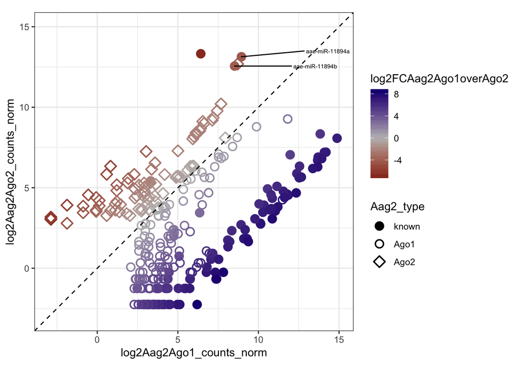

```r
known_filtered <- read.delim("/Users/kathryn/Reprocess_all_paper_datasets/Supp_Figs/known_miRNAs_allcols.txt", sep = "\t", header = TRUE)

novel_filtered <- read.delim("/Users/kathryn/Reprocess_all_paper_datasets/Supp_Figs/novel_miRNAs_filtered_counts_all_info.txt", sep = "\t", header = TRUE)

known_filtered <- known_filtered[,c(1:150)]

sRNA_all_filtered <- rbind(known_filtered, novel_filtered)

#final filtering: has to have reads in 1/3 of smaples and Ab is 10X above sample, nhi = 2
sRNA_Aag2nhi <- subset(sRNA_all_filtered, sRNA_all_filtered$Aag2_Ago1_BCsample > 5 & sRNA_all_filtered$Aag2_Ago1_nhipeaks > 1 | sRNA_all_filtered$Aag2_Ago2_BCsample > 3 & sRNA_all_filtered$Aag2_Ago2_nhipeaks > 1 )

sRNA_aegyptinhi <- subset(sRNA_all_filtered, sRNA_all_filtered$aegypti_Ago1_BCsample > 4 & sRNA_all_filtered$aegypti_Ago1_nhipeaks > 1 | sRNA_all_filtered$aegypti_Ago2_BCsample > 2 & sRNA_all_filtered$aegypti_Ago2_nhipeaks > 1 )

#write.table(sRNA_all_filtered, file = "/Users/kathryn/Reprocess_all_paper_datasets/Supp_Figs/all_miRNAs_final_cells_aegypti_for_scatter.txt", quote = FALSE, sep = "\t", col.names = TRUE, row.names = FALSE)

#write.table(sRNA_aegyptinhi, file = "/Users/kathryn/Reprocess_all_paper_datasets/all_miRNAs_final_aegypti_for_scatter.txt", quote = FALSE, sep = "\t", col.names = TRUE, row.names = FALSE)

#write.table(sRNA_Aag2nhi, file = "/Users/kathryn/Reprocess_all_paper_datasets/all_miRNAs_final_Aag2_for_scatter.txt", quote = FALSE, sep = "\t", col.names = TRUE, row.names = FALSE)


ggplot(aes(x=log2Aag2Ago1_counts_norm,y=log2Aag2Ago2_counts_norm), data=sRNA_Aag2nhi) +
  geom_point(aes(colour=log2FCAag2Ago1overAgo2, shape = Aag2_type), size=3, stroke=1) + scale_shape_manual(values = c(19,1,5)) +
  scale_colour_gradient2(high="#1B0B80", mid ="gray", low="#8A0F09") +
  theme_bw() + xlim(-3,15) + ylim(-3,15) +
  coord_equal() +
  geom_abline(intercept = 0, slope = 1, linetype="dashed") + geom_text_repel(data = sRNA_Aag2nhi[grepl("aae-miR-11894", sRNA_Aag2nhi$miRNA),], aes(label = miRNA), size=2, force=10, nudge_x = 5)
```

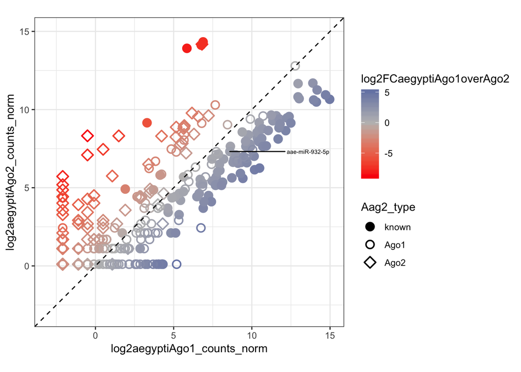

```r
ggplot(aes(x=log2aegyptiAgo1_counts_norm,y=log2aegyptiAgo2_counts_norm), data=sRNA_all_filtered) +
  geom_point(aes(colour=log2FCaegyptiAgo1overAgo2, shape = Aag2_type), size=3, stroke=1) + scale_shape_manual(values = c(19,1,5)) +
  scale_colour_gradient2(high="#3360A9", mid ="gray", low="#FA0F0C") +
  theme_bw() + xlim(-3,15) + ylim(-3,15) +
  coord_equal() +
  geom_abline(intercept = 0, slope = 1, linetype="dashed") + geom_text_repel(data = sRNA_all_filtered[grepl("miR-932", sRNA_all_filtered$miRNA),], aes(label = miRNA), size=2, force=10, nudge_x = 5)
```

## Get length distribution by type for Figure S2A and S2B

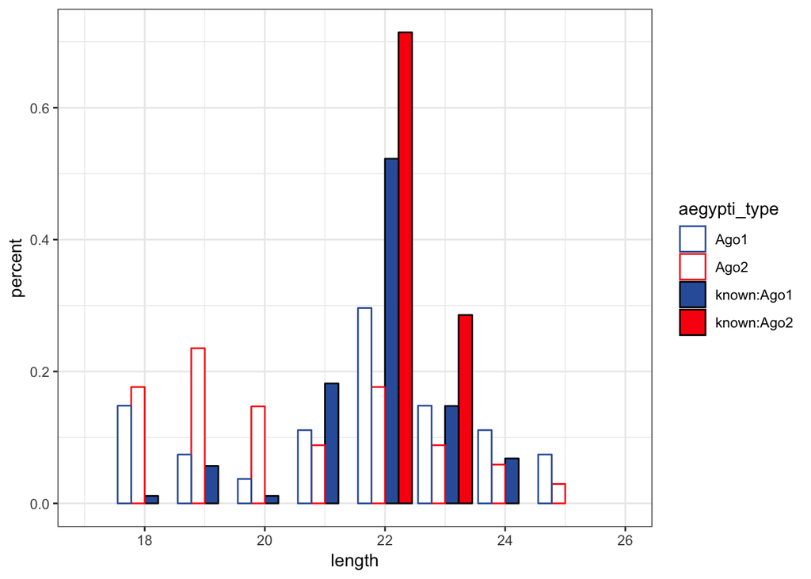

```r
##append  full length sequences for known to get length
aae_df <- as.data.frame(aae)
sRNA_all_filtered <- merge(sRNA_all_filtered, aae_df, by.x = "miRNA", by.y =0, all.x = TRUE)
sRNA_all_filtered$x <- ifelse(is.na(sRNA_all_filtered$x), paste0(sRNA_all_filtered$miRNA), paste0(sRNA_all_filtered$x))

sRNA_all_filtered$length <- nchar(sRNA_all_filtered$x)

#update type columns to classify known miRNAs as Ago1- or Ago2-associated
sRNA_all_filtered$aegypti_type <- ifelse(sRNA_all_filtered$log2FCaegyptiAgo1overAgo2 > 0 & sRNA_all_filtered$aegypti_type == "known", paste0(sRNA_all_filtered$aegypti_type, ":Ago1"), paste0(sRNA_all_filtered$aegypti_type))

sRNA_all_filtered$aegypti_type <- ifelse(sRNA_all_filtered$aegypti_type == "known", paste0(sRNA_all_filtered$aegypti_type, ":Ago2"), paste0(sRNA_all_filtered$aegypti_type))

sRNA_all_filtered$Aag2_type <- ifelse(sRNA_all_filtered$log2FCAag2Ago1overAgo2 > 0 & sRNA_all_filtered$Aag2_type == "known", paste0(sRNA_all_filtered$Aag2_type, ":Ago1"), paste0(sRNA_all_filtered$Aag2_type))

sRNA_all_filtered$Aag2_type <- ifelse(sRNA_all_filtered$Aag2_type == "known", paste0(sRNA_all_filtered$Aag2_type, ":Ago2"), paste0(sRNA_all_filtered$Aag2_type))

aegypti_stats <- sRNA_all_filtered[sRNA_all_filtered$miRNA %in% sRNA_aegyptinhi$miRNA,] %>% group_by(.dots=c("aegypti_type", "length")) %>% dplyr::select(group_cols()) %>% mutate(count = n())

aegypti_stats <- unique(aegypti_stats)
aegypti_statsf <- aegypti_stats %>% group_by(aegypti_type) %>% mutate(nrow = sum(count), percent=count/nrow)

cell_stats <- sRNA_all_filtered[sRNA_all_filtered$miRNA %in% sRNA_Aag2nhi$miRNA,] %>% group_by(.dots=c("Aag2_type", "length")) %>% dplyr::select(group_cols()) %>% mutate(count = n())
cell_stats <- unique(cell_stats)
cell_statsf <- cell_stats %>% group_by(Aag2_type) %>% mutate(nrow = sum(count), percent=count/nrow)

ggplot(aegypti_statsf, aes(x = length, y = percent, fill=aegypti_type, color=aegypti_type)) + geom_bar(stat = "identity", position=position_dodge(preserve = "single")) + xlim(17, 26) + scale_fill_manual(values = c("white", "white", "#3360A9", "#FA0F0C")) + scale_colour_manual(values = c("#3360A9", "#FA0F0C", "black", "black")) + theme_bw()
```

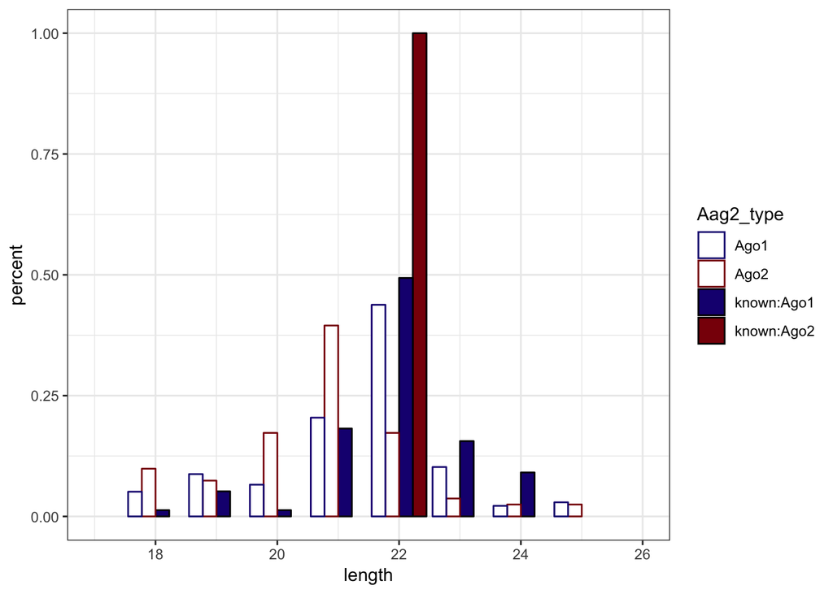

```r
ggplot(cell_statsf, aes(x = length, y = percent, fill=Aag2_type, color=Aag2_type)) + geom_bar(stat = "identity", position=position_dodge(preserve = "single")) + xlim(17, 26) + scale_fill_manual(values = c("white", "white", "#1B0B80", "#8A0F09")) + scale_colour_manual(values = c("#1B0B80", "#8A0F09", "black", "black")) + theme_bw()
```

## sClassify known and novel AGO1-associated small RNAs detected in Aag2 cells compared to whole mosquitoes, Figure S2C and S2D

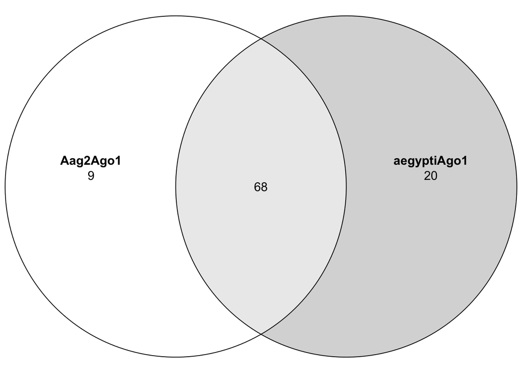

```r
#venn
AeA1 <- unique(subset(sRNA_all_filtered$miRNA, sRNA_all_filtered$aegypti_type == "known:Ago1"))
AeA1 <- AeA1[AeA1 %in% sRNA_aegyptinhi$miRNA]
AeA1n <- unique(subset(sRNA_all_filtered$miRNA, sRNA_all_filtered$aegypti_type == "Ago1"))
AeA1n <- AeA1n[AeA1n %in% sRNA_aegyptinhi$miRNA]
AA1 <- unique(subset(sRNA_all_filtered$miRNA, sRNA_all_filtered$Aag2_type == "known:Ago1"))
AA1 <- AA1[AA1 %in% sRNA_Aag2nhi$miRNA]
AA1n <- unique(subset(sRNA_all_filtered$miRNA, sRNA_all_filtered$Aag2_type == "Ago1"))
AA1n <- AA1n[AA1n %in% sRNA_Aag2nhi$miRNA]
filt_known <- list(Aag2Ago1 = AA1, aegyptiAgo1 = AeA1)
filt_novel <- list(Aag2Ago1n = AA1n, aegyptiAgo1n = AeA1n)
plot(venn(filt_known))
```

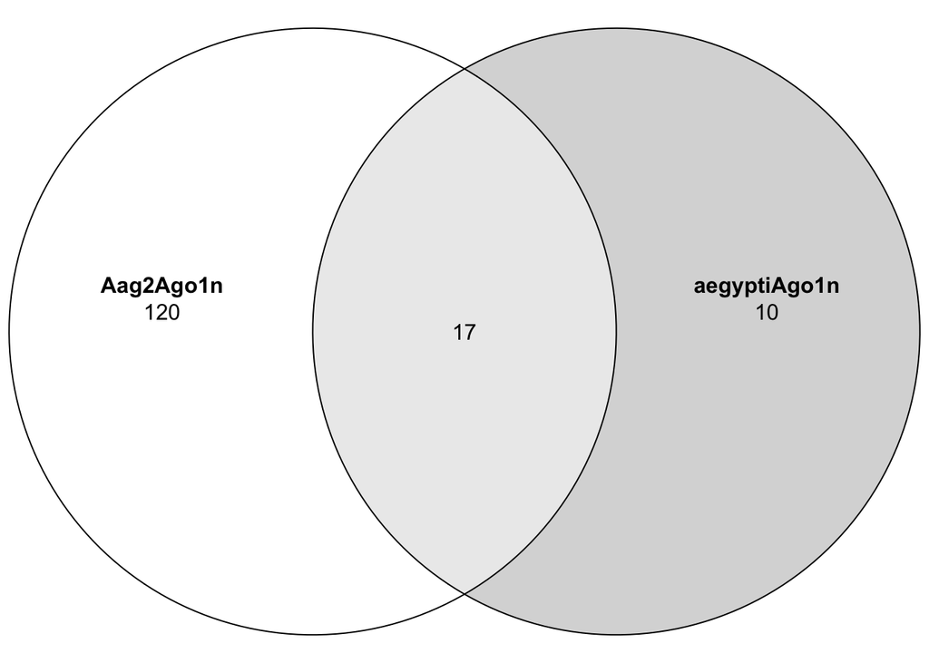

```r
plot(venn(filt_novel))
```